# Anàlisi de la cohort de UCEC utilitzant informació de MCN

## Preparació de les dades per a l’anàlisi

El fitxer de dades amb informació de l’estat WGD (Bielski) conté 241 casos de la cohort de UCEC.

Tenim 587 fitxers de recomptes de la cohort de UCEC.

L’anàlisi inclourà 240 mostres, 203 mostres sense WGD i 37 mostres amb WGD. Un 15% de les mostres de l’anàlisi han patit WGD.

## Pre-processament de les dades

Per a la filtració s’ha utilitzat un llindar de CPM de 0.24 i s’han filtrat 38880 gens, és a dir un 64% dels gens que teníem inicialment.

El rang de valors dels factors de normalització és de 0.6179286, 1.3003982.

## Exploració de les dades

### Gràfics de densitat

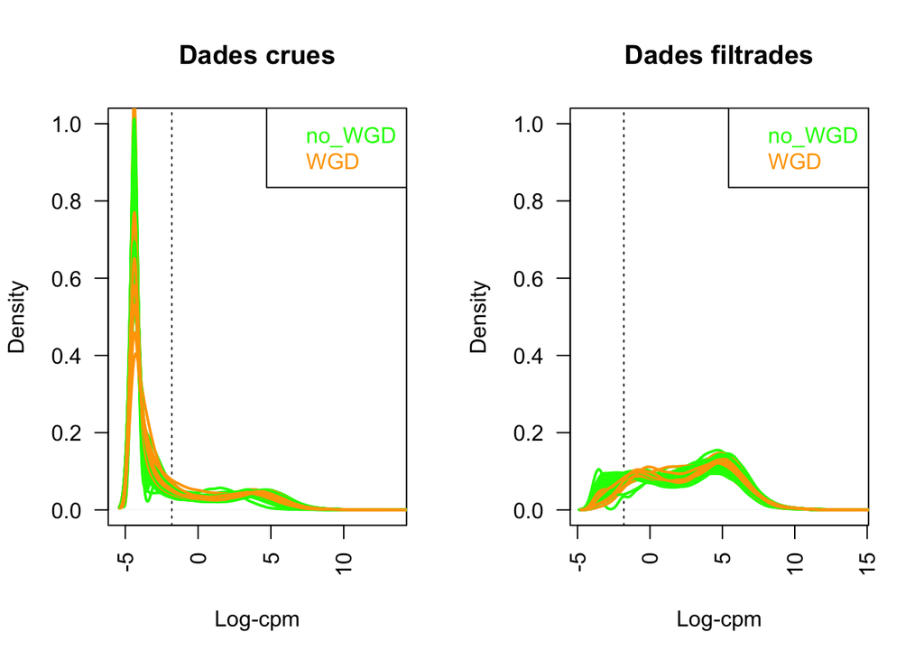

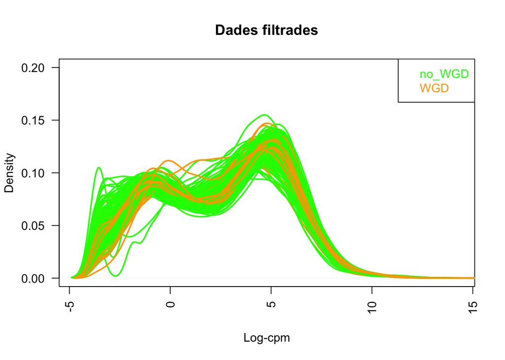

### Gràfic d’escalat multidimensional

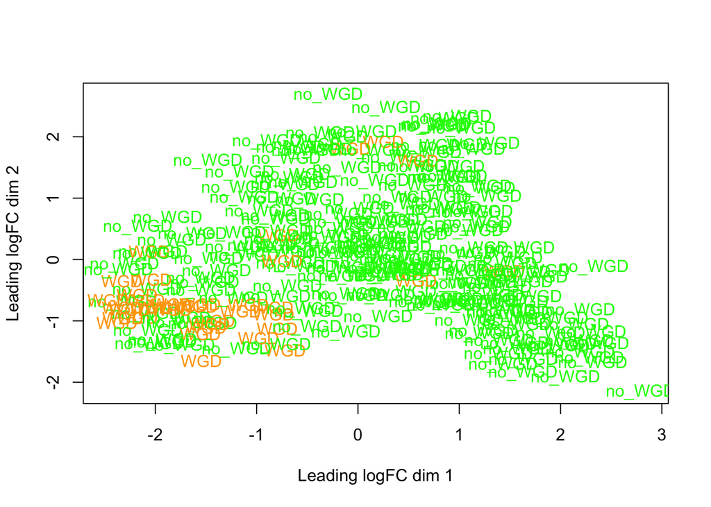

### Heatmap del gens més variables

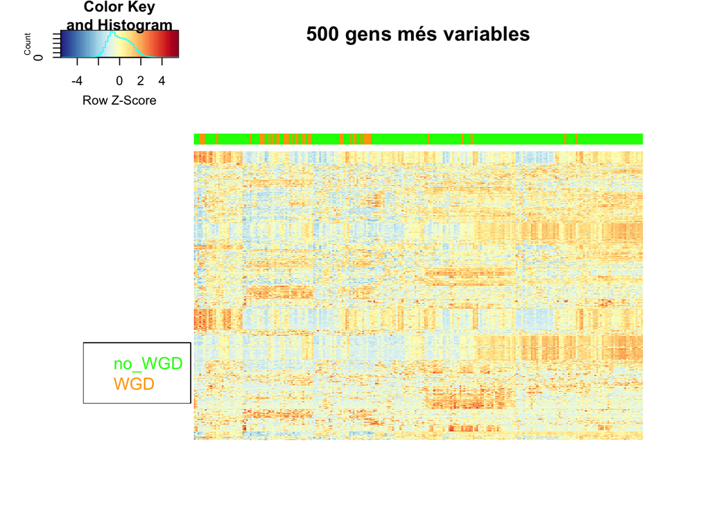

## Resultats de l’anàlisi d’expressió diferencial

### Nombre de gens diferencialment expressats

Contrastos amb p-valor ajustat (FDR) inferior a 0.05:

```
##        WGDvsNoWGD
## Down         3188
## NotSig      14652
## Up           3763
```

Contrastos amb p-valor sense ajustar inferior a 0.05 i valor absolut de log2-fold-change superior a 0.5 , aproximadament equivalent a un fold-change de 0.7 i 1.4:

```
##        WGDvsNoWGD
## Down         2210
## NotSig      16584
## Up           2809
```

### Llista de gens ordenats per significació

```
##       ensembl_gene_id hgnc_symbol    logFC      P.Value    adj.P.Val
## 15173 ENSG00000198910       L1CAM 4.426722 3.281504e-24 7.089034e-20
## 13207 ENSG00000181690       PLAG1 2.886324 1.046003e-22 1.129840e-18
## 5125  ENSG00000124440       HIF3A 3.451864 1.608635e-22 1.158378e-18
## 4281  ENSG00000116544      DLGAP3 2.925221 1.930655e-21 1.042698e-17
## 17989 ENSG00000240086             3.484551 2.841293e-21 1.227609e-17
## 16085 ENSG00000214617    SLC6A10P 4.130784 6.166064e-21 2.220091e-17
## 15499 ENSG00000205002        AARD 3.067971 4.408564e-20 1.360546e-16
## 11396 ENSG00000169418        NPR1 2.341921 1.036201e-19 2.798131e-16
## 6963  ENSG00000137962    ARHGAP29 1.844892 1.394620e-19 3.347552e-16
## 5843  ENSG00000130775     THEMIS2 1.479070 4.006264e-19 8.654733e-16
## 19054 ENSG00000255624   C10orf88B 2.721638 8.401231e-19 1.615198e-15
## 20247 ENSG00000269190      FBXO17 2.317398 8.972074e-19 1.615198e-15
## 5059  ENSG00000124092       CTCFL 4.423043 1.080013e-18 1.794732e-15
## 3059  ENSG00000106066        CPVL 1.907408 1.219132e-18 1.881208e-15
## 19697 ENSG00000261586             2.520574 4.606300e-18 6.633993e-15
## 13671 ENSG00000184697       CLDN6 4.947770 7.445285e-18 1.005253e-14
## 8915  ENSG00000154277       UCHL1 3.382959 3.225134e-17 4.003070e-14
## 9031  ENSG00000155622       XAGE2 2.900363 3.520730e-17 4.003070e-14
## 16180 ENSG00000215452     ZNF663P 2.952472 3.425691e-17 4.003070e-14
## 13400 ENSG00000183023      SLC8A1 1.674720 5.514710e-17 5.956714e-14
```

### Representació gràfica dels resultats

#### Gràfic mitjana-diferència

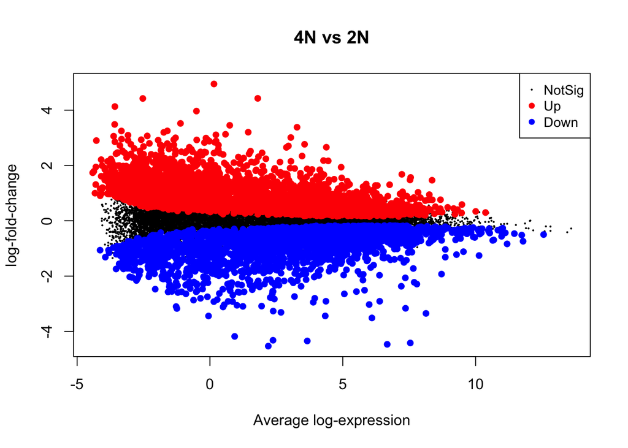

#### Gràfic de volcà

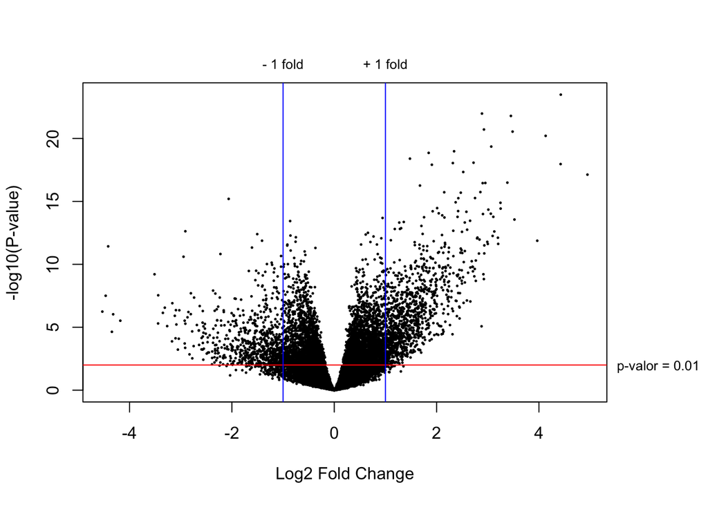

#### Heatmap dels gens més significatius

100 gens amb p-valor ajustat més baix:

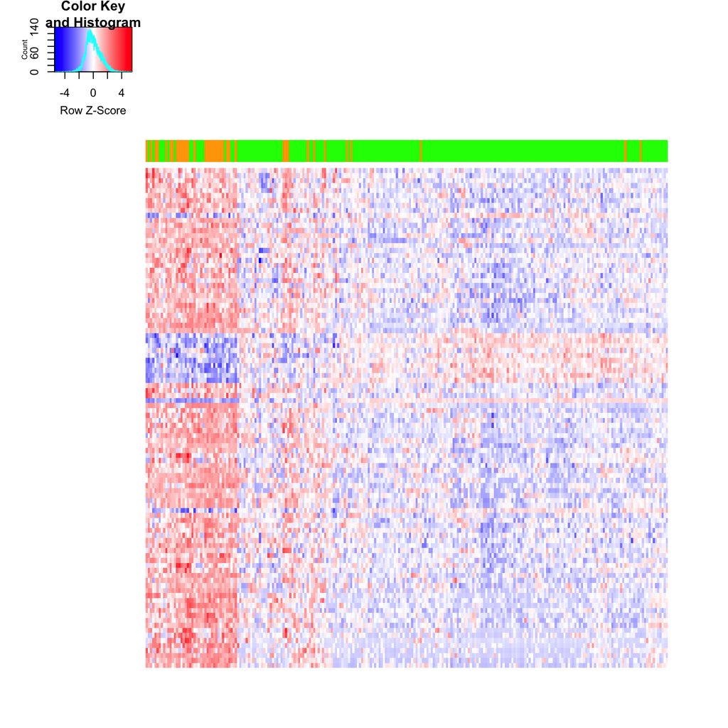

100 gens amb p-valor ajustat més baix després d’haver filtrat per aquells gens amb un logFC en valor absolut superior a 0.5 (aproximadament equivalent a FC superior a 1.4 o inferior a 0.7):

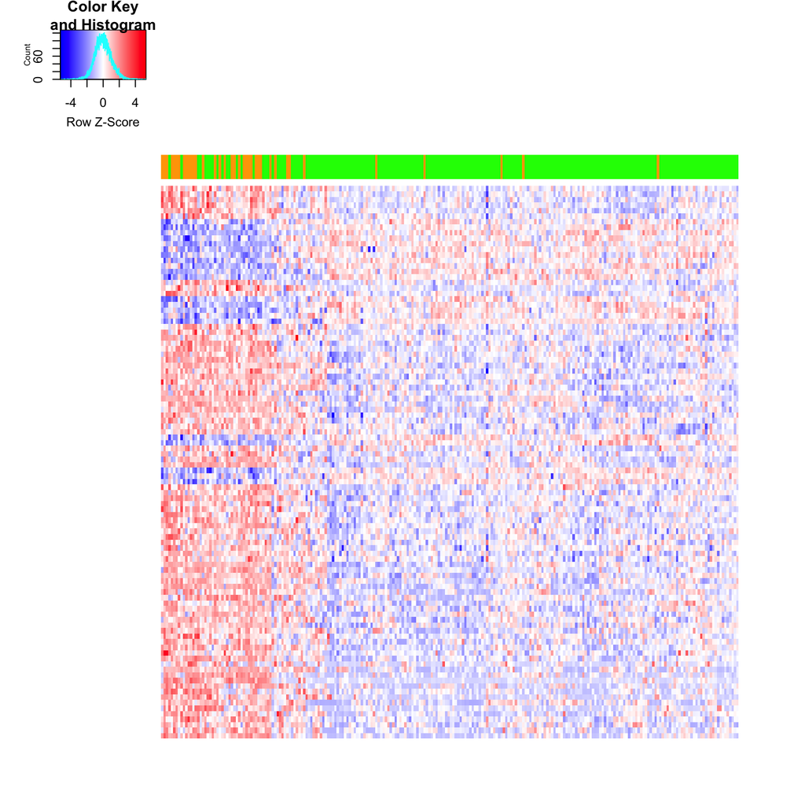

## Resultats de l’anàlisi d’enriquiment amb permutació de gene sets

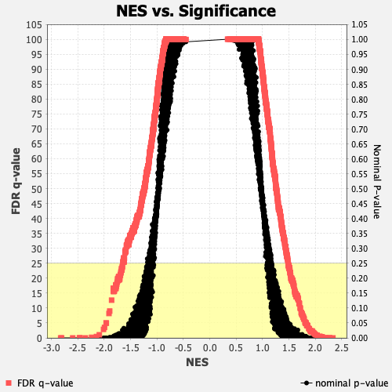

Termes enriquits al grup WGD

| NAME | FDR.q.val | NES |
| --- | --- | --- |
| GO_MEIOTIC_CHROMOSOME_SEGREGATION | 0.0000000 | 2.332407 |
| GO_CHROMOSOME_ORGANIZATION_INVOLVED_IN_MEIOTIC_CELL_CYCLE | 0.0003963 | 2.270209 |
| GO_FEMALE_MEIOTIC_NUCLEAR_DIVISION | 0.0002642 | 2.260220 |
| GO_HOMOLOGOUS_CHROMOSOME_SEGREGATION | 0.0010053 | 2.195141 |
| GO_CHROMOSOME_SEGREGATION | 0.0032388 | 2.130395 |
| GO_MEIOTIC_CELL_CYCLE_PROCESS | 0.0036430 | 2.117441 |
| GO_NEGATIVE_REGULATION_OF_METAPHASE_ANAPHASE_TRANSITION_OF_CELL_CYCLE | 0.0039321 | 2.109117 |
| GO_NUCLEAR_CHROMOSOME_SEGREGATION | 0.0036403 | 2.102129 |
| GO_CELL_CYCLE_DNA_REPLICATION | 0.0045898 | 2.091529 |
| GO_SYNAPSIS | 0.0049374 | 2.080227 |
| GO_NEGATIVE_REGULATION_OF_CHROMOSOME_SEGREGATION | 0.0045630 | 2.077967 |
| GO_CALCIUM_INDEPENDENT_CELL_CELL_ADHESION_VIA_PLASMA_MEMBRANE_CELL_ADHESION_MOLECULES | 0.0085037 | 2.033859 |
| GO_MEIOSIS_I_CELL_CYCLE_PROCESS | 0.0081588 | 2.031666 |
| GO_NEGATIVE_REGULATION_OF_NUCLEAR_DIVISION | 0.0106507 | 2.004675 |
| GO_RECOMBINATIONAL_REPAIR | 0.0132854 | 1.988222 |
| GO_MEIOTIC_CELL_CYCLE | 0.0157458 | 1.973120 |
| GO_CHROMOSOME_SEPARATION | 0.0180626 | 1.961118 |
| GO_REGULATION_OF_CHROMOSOME_SEPARATION | 0.0231866 | 1.938158 |
| GO_DNA_DEPENDENT_DNA_REPLICATION | 0.0225205 | 1.937162 |
| GO_SISTER_CHROMATID_SEGREGATION | 0.0214346 | 1.936874 |

Termes enriquits al grup no_WGD

| NAME | FDR.q.val | NES |
| --- | --- | --- |
| GO_AXONEME_ASSEMBLY | 0.0000000 | -2.826342 |
| GO_CILIUM_MOVEMENT | 0.0000000 | -2.807987 |
| GO_AXONEMAL_DYNEIN_COMPLEX_ASSEMBLY | 0.0000000 | -2.597352 |
| GO_MOTILE_CILIUM_ASSEMBLY | 0.0000000 | -2.470426 |
| GO_MICROTUBULE_BUNDLE_FORMATION | 0.0000000 | -2.467739 |
| GO_EXTRACELLULAR_TRANSPORT | 0.0000000 | -2.458039 |
| GO_CILIUM_MOVEMENT_INVOLVED_IN_CELL_MOTILITY | 0.0000000 | -2.356862 |
| GO_CILIUM_OR_FLAGELLUM_DEPENDENT_CELL_MOTILITY | 0.0018773 | -2.238985 |
| GO_CILIUM_ORGANIZATION | 0.0044910 | -2.147186 |
| GO_INTERLEUKIN_8_SECRETION | 0.0104849 | -2.093347 |
| GO_REGULATION_OF_EPIDERMAL_CELL_DIFFERENTIATION | 0.0286683 | -2.013955 |
| GO_SPERM_MOTILITY | 0.0350104 | -1.994966 |
| GO_PANCREAS_DEVELOPMENT | 0.0503565 | -1.965116 |
| GO_REGULATION_OF_CILIUM_MOVEMENT | 0.0491074 | -1.961007 |
| GO_OLIGOSACCHARIDE_LIPID_INTERMEDIATE_BIOSYNTHETIC_PROCESS | 0.0818032 | -1.910545 |
| GO_POSITIVE_REGULATION_OF_EPIDERMAL_CELL_DIFFERENTIATION | 0.0898673 | -1.896801 |
| GO_MAMMARY_GLAND_DUCT_MORPHOGENESIS | 0.1264235 | -1.861161 |
| GO_INTRACILIARY_TRANSPORT | 0.1662674 | -1.829360 |
| GO_ENDOCARDIAL_CUSHION_DEVELOPMENT | 0.1583178 | -1.829014 |
| GO_ORGAN_INDUCTION | 0.1550804 | -1.826312 |

## Anàlisis d’immunitat

### ESTIMATE

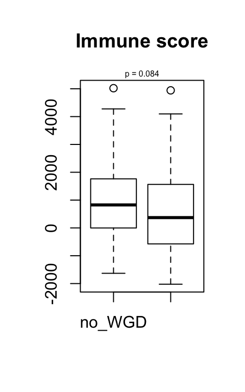

### Immunophenoscore

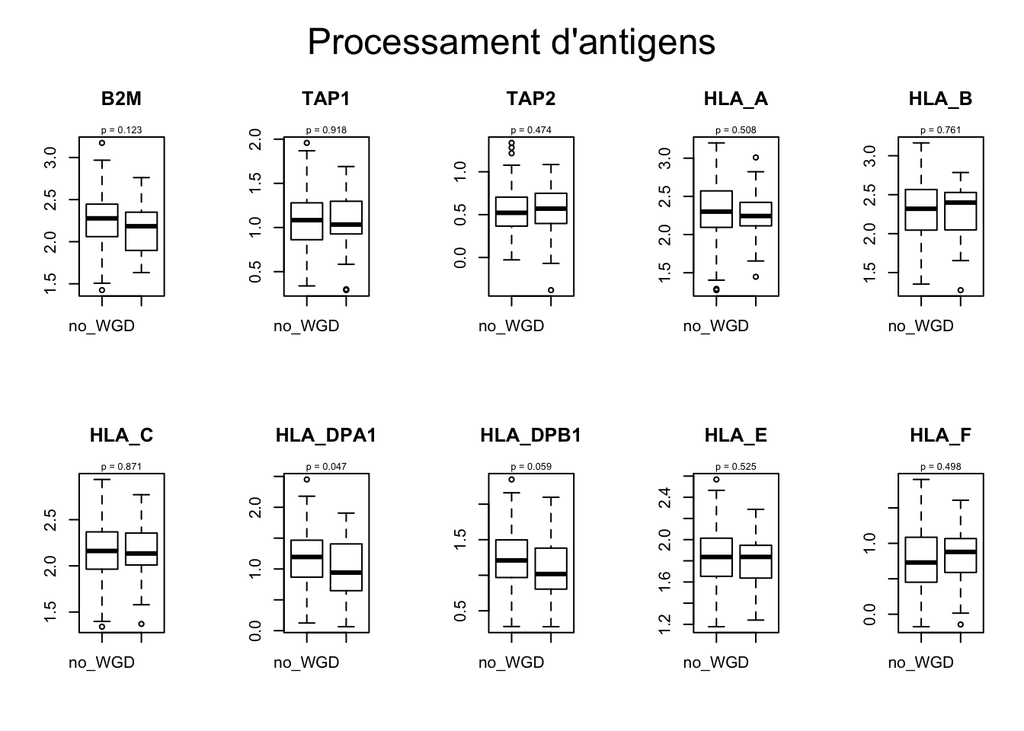

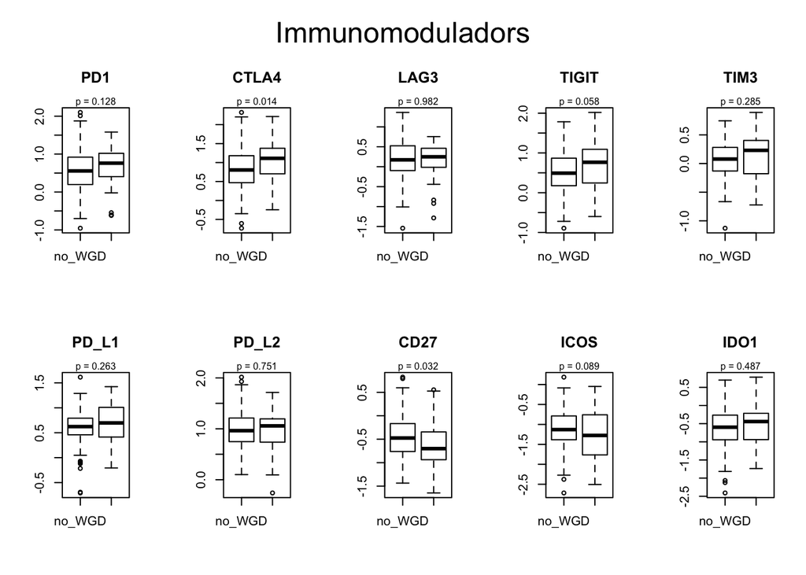

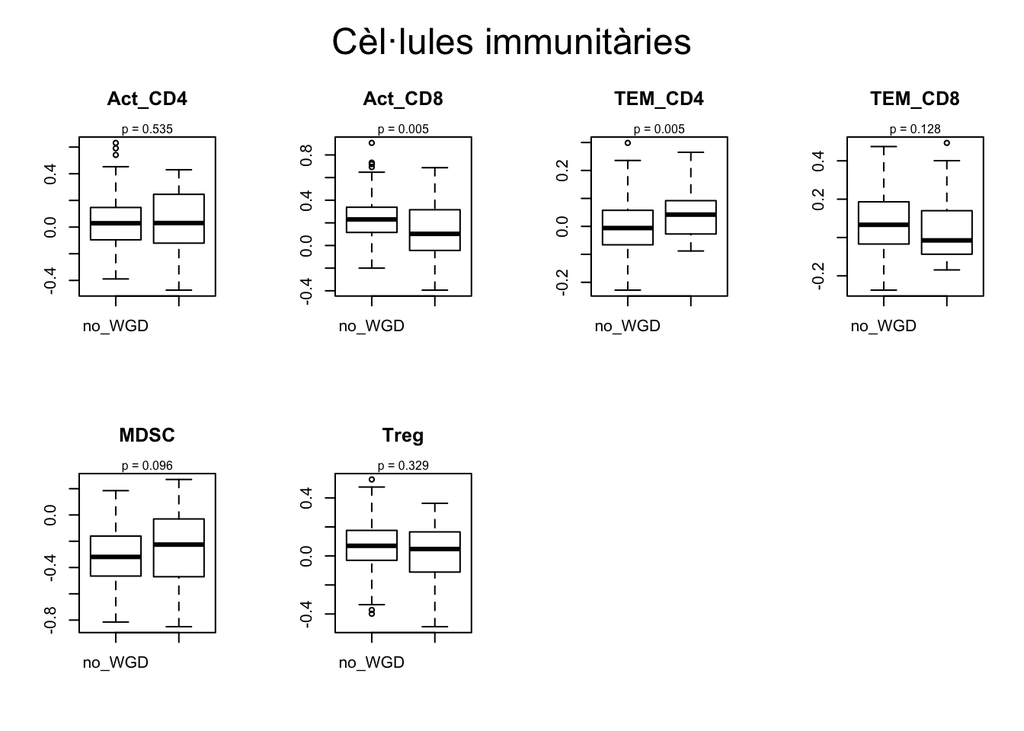

### Signatura 12-Chemokines

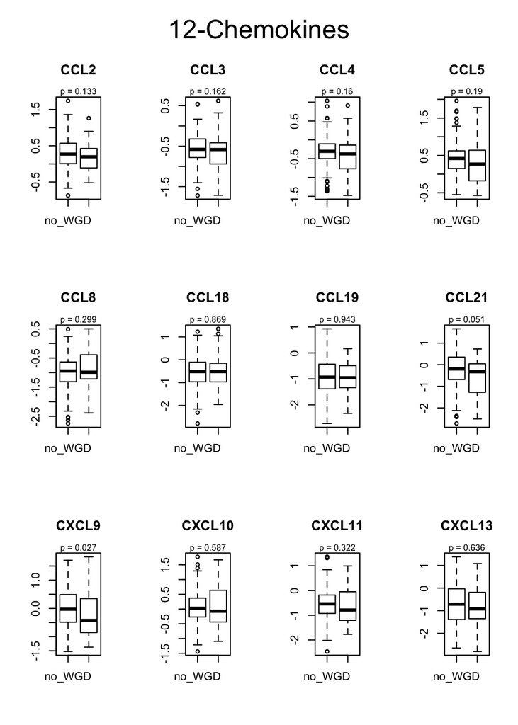